# Next-Word Predictor

2026-07-23

## The Problem

- Mobile keyboards need to suggest the next word **instantly** as you type.
- Built on ~3.8M lines of blogs, news, and tweets (SwiftKey corpus).
- Constraints that matter as much as accuracy:
  - **Size** — must fit comfortably in a phone’s / free-tier server’s memory.
  - **Speed** — a suggestion that arrives after you’ve already typed the word is useless.

## How the Model Works

- **Stupid Backoff**: predict from the longest context we’ve seen, and fall back to shorter contexts when we haven’t.

```
"I want to go to the"  →  try 3-word context "go to the"
                          not enough matches? → try "to the"
                          still not enough?   → try "the"
                          still not enough?   → most common words overall
```

- Each backoff step is discounted (×0.4) so longer, more specific contexts are always preferred when available.
- Rare words (seen only once) are folded into a shared `<unk>` token before counting — this bounds vocabulary size without losing the context they provided.
- Only the top 5 candidate words are kept per context — predictions never need more, and this is most of the memory savings.

## Performance

| Metric | Value |
| --- | --- |
| accuracy@1 | 0.16 |
| accuracy@2 | 0.23 |
| accuracy@3 | 0.27 |
| avg_latency_ms | 2.93 |
| total_predictions | 2000.00 |
| model_size_mb | 221.81 |

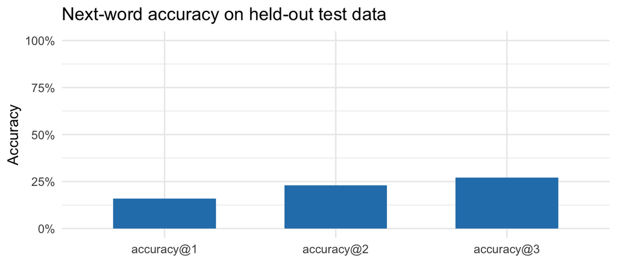

## The App

- A Shiny app takes a phrase and shows the top 3 predicted next words as clickable buttons — click one to append it and keep typing.
- Predictions update live as you type (debounced ~300ms).
- Try it: **[miguelrzazo.shinyapps.io/next-word-predictor](https://miguelrzazo.shinyapps.io/next-word-predictor/)**

## Takeaways & Next Steps

- Stupid Backoff trades a small amount of accuracy for simplicity and speed versus Kneser-Ney smoothing — no discount estimation needed, and lookups are O(1) keyed joins.
- Limitations: doesn’t use semantic similarity, and rare/unseen phrasing still falls back all the way to generic word frequency.
- Future improvements: word embeddings for semantic backoff, user-specific adaptation, larger training sample if size/latency budget allows.